# Qualidade de vida relacionada à saúde no Distrito Federal

25 de outubro de 2018

## Objeto

Este trabalho tem como objeto central a qualidade de qualidade de vida relacionada à saúde.

Como definição, a qualidade de qualidade de vida relacionada à saúde pode ser compreendida como o *"valor atribuído à duração da vida, modificado pelos prejuízos, estados funcionais e oportunidades sociais que são influenciados por doença, dano, tratamento ou políticas de saúde."* (Patrick & Erickson, 1993)

## Objetivos

Com o intuito de estudar os indicadores de qualidade de vida relacionada à saúde e sua relação com a presença de doenças crônicas e fatores socioeconomicos em adultos residentes no Distrito Federal, foram definidos os seguintes objetivos:

- Estabelecer as estimativas de qualidade de vida relacionada à saúde
- Analisar a relação com a presença de doenças crônicas
- Analisar a relação com indicadores socioeconomicos

## Contexto

- A qualidade de vida é um indicador e um objetivo fundamental das políticas de promoção de saúde (Brasil, 2015)
- Dados demonstram que as doenças crônicas estão associadas a impactos negativos na qualidade de vida (Wu, 2014)
- Adicionalmente, fatores sociodemográficos são modificadores dessas estimativas (Navega, 2007)
- Obtido com o instrumento EQ-5D, o QALY é um indicador consistente de qualidade de vida relacionada à saúde, disponível em estudos clínicos e de base populacional (Brooks, 1996)

## Métodos

A presente análise fez uso da base dados da pesquisa "QALY DF". Trata-se de um inquérito populacional com as seguintes caracteríticas:

- Coleta de dados no primeiro semestre de 2012;
- Amostragem probabilística em dois estágios (setor censitário e domicílio)
- Representativa de adultos (18 a 65 anos de idade) residentes nas regiões administrativas do Distrito Federal
- Coleta de dados sócio, econômico, demográficos e sobre a situação de saúde em entrevistas presenciais
- Os valores de **QALY** dentro da escala de **0 (morte)** a **1 (saúde plena)**

## Métodos

Para esta análise foram utilizados os seguintes pacotes estatísticos do software R:

- tidyverse
- survey
- srvyr
- foreign

## Resultados

A amostra do estudo incluiu um total de **1820** indivíduos com idade média de **38.38** anos, sem diferenças significativas em relação à representação das classes sociais.

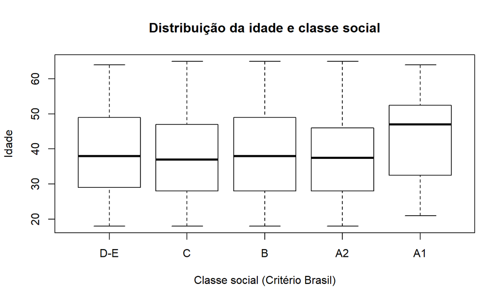

## Resultados

A amostra teve um índice de de utilidade (QALY) médio de **0,88 (IC95%: 0,87 a 0,89)**

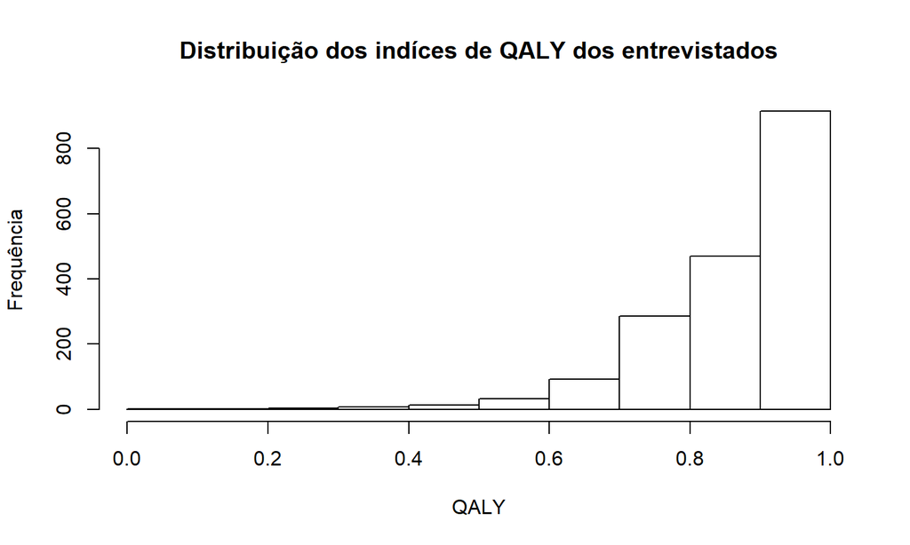

## Resultados

Um total de **711** indivíduos referiu ter sido diagnosticado com alguma doença crônica, estando significativamente associados a índices menores de QALY.

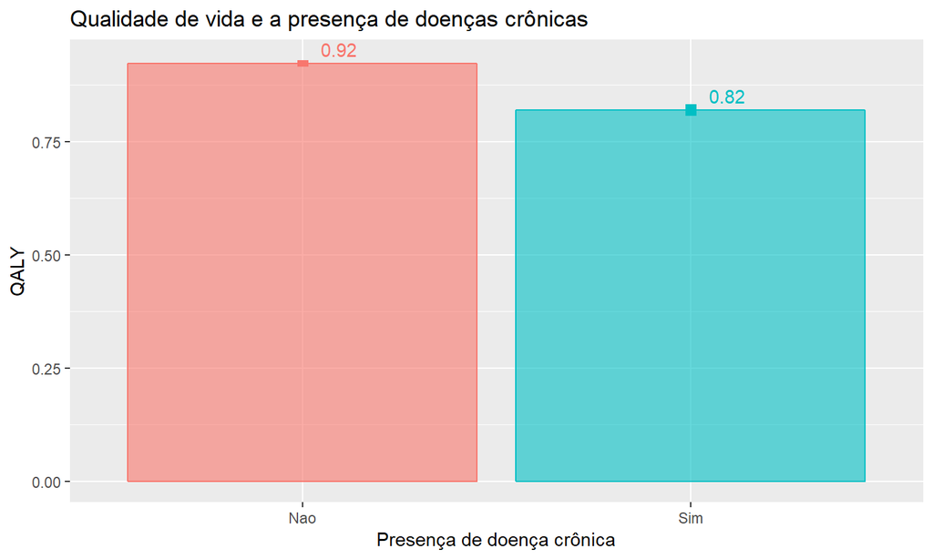

## Resultados

Quando considerado o nível de classe social, é possível observar menores índices de QALY na classe baixa quando comparado à alta.

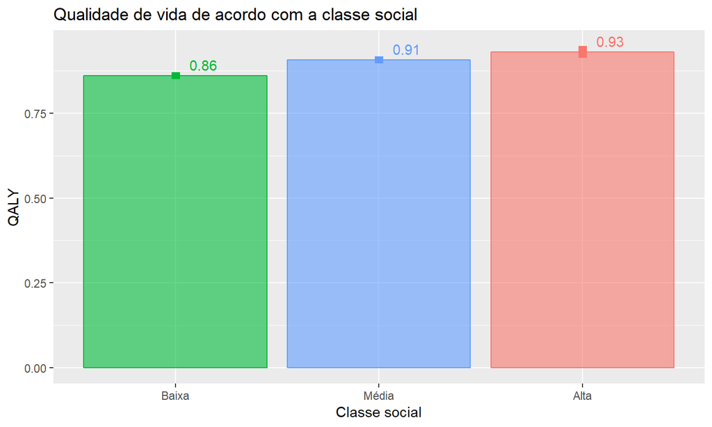

## Resultados

A distribuição dos índices de QALY apresenta uma tendência de valores menores de acordo com a presença de doenças crônicas e o aumento da idade dos indivíduos:

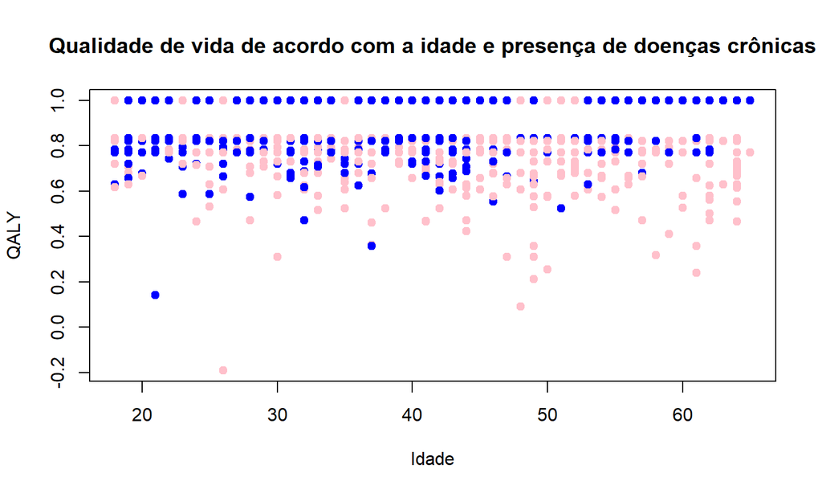

## Conclusões

Com base nos resultados é possível concluir que:

- A maioria da população adulta do Distrito Federal apresenta uma boa percepção de qualidade de vida.
- Há uma uma concentração de menores valores de qualidade de vida nas idades mais avançadas
- A presença de doenças crônicas tem associação significativa com menores índices de qualidade de vida.
- Quando considerado o nível de classe social, também é possível observar menores índices de QALY nas classes mais baixas.
- Políticas públicas para promoção da qualidade de vida precisam atuar no envelhecimento, nas doenças crônicas no desenvolvimento socioeconômico.

## Referências bibliográficas

- Brasil. Ministério da Saúde. Secretaria de Vigilância em Saúde. Secretaria de Atenção à Saúde. Política Nacional de Promoção da Saúde: PNPS: revisão da Portaria MS/GM no 687, de 30 de março de 2006. Brasília: Ministério da Saúde; 2015. 36 p.
- Brooks R. EuroQol: the current state of play. Health Policy. 1996 Jul;37(1):53-72.
- Patrick DL, Erickson P. Concepts of health-related quality of life. In: Murray CJL, editors. Designing and implementing a national burden of disease study. New York: Harvard Center for Population and Development Studies; 1993. p. 82-99.
- Navega MT, Oishi J. Comparação da qualidade de vida relacionada à saúde entre mulheres na pós-menopausa praticantes de atividade física com e sem osteoporose. Rev Bras Reumatol. 2007 Aug;47(4):258-64.
- Wu M, Brazier JE, Kearns B, Relton C, Smith C, Cooper CL. Examining the impact of 11 long-standing health conditions on health-related quality of life using the EQ-5D in a general population sample. Eur J Health Econ. 2014 Jan 10.